# Valeurs Extrêmes

Marlène Chevalier

02 février 2020

# Sujet : précipitations quotidiennes à Fort Collins, au Colorado

La quantité de précipitations quotidiennes est mesurée en pouces. Les données ont été enregistrées chaque jour entre le 01/01/1900 et le 31/12/1999, soient 36524 relevés de précipitations.

source : data(Fort)

Il s’agit d’étudier les valeurs extrêmes de cette série en utilisant et comparant deux approches :

- Generalized Extreme Value (GEV) : distribution des extrêmes generalisés
- Generalized Pareto Distribution (GPD) : distribution generalisée de Pareto

# Description de la série

Les précipitations quotidiennes (variable *Prec*) sont comprises entre 0 et 4.63 pouces (=11.76cm). Elles sont en plus grande partie proches de 0 pouce : médiane à 0 et moyenne à 0.04 pouces.Les niveaux sont plus élévés au printemps (d’avril à juin), plus faibles en hiver (de novembre à février).

```
##       obs             tobs           month             day
##  Min.   :    1   Min.   :  1.0   Min.   : 1.000   Min.   : 1.00
##  1st Qu.: 9132   1st Qu.: 92.0   1st Qu.: 4.000   1st Qu.: 8.00
##  Median :18263   Median :183.0   Median : 7.000   Median :16.00
##  Mean   :18263   Mean   :183.1   Mean   : 6.523   Mean   :15.73
##  3rd Qu.:27393   3rd Qu.:274.0   3rd Qu.:10.000   3rd Qu.:23.00
##  Max.   :36524   Max.   :366.0   Max.   :12.000   Max.   :31.00
##       year           Prec
##  Min.   :1900   Min.   :0.00000
##  1st Qu.:1925   1st Qu.:0.00000
##  Median :1950   Median :0.00000
##  Mean   :1950   Mean   :0.04181
##  3rd Qu.:1974   3rd Qu.:0.00000
##  Max.   :1999   Max.   :4.63000
```

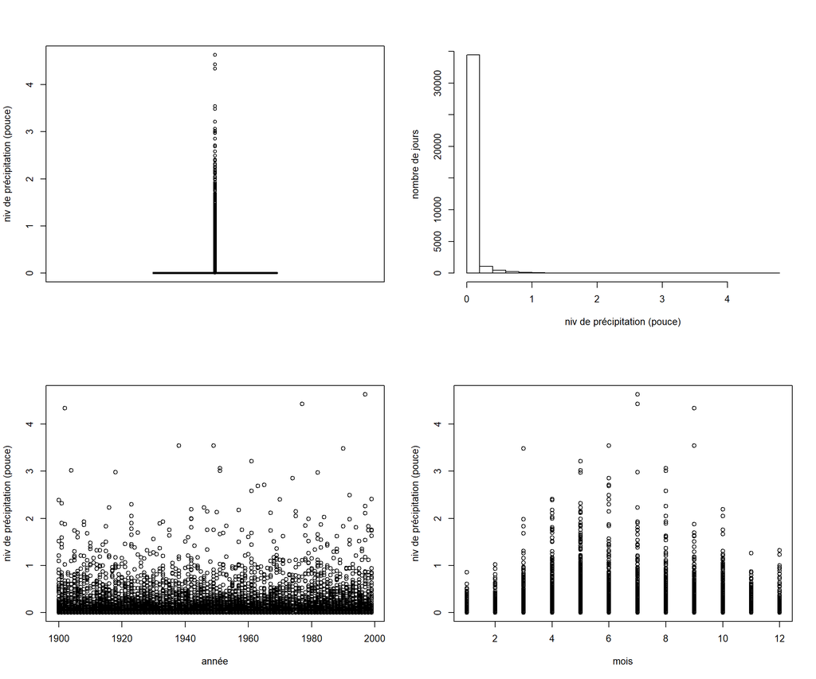

# Modélisation Generalized Extreme Value (GEV) : loi des maxima de la série

Nous avons observé graphiquement de la saisonnalité (printemps/hiver). Pour éviter ces effets et avoir des données équiréparties, découpons d’abord les données par bloc d’un an et sélectionnons le maximum annuel dans chacun des blocs (*fonction blockmaxxer*). La matrice des données par bloc aura donc 100 lignes (au lieu de 36524).

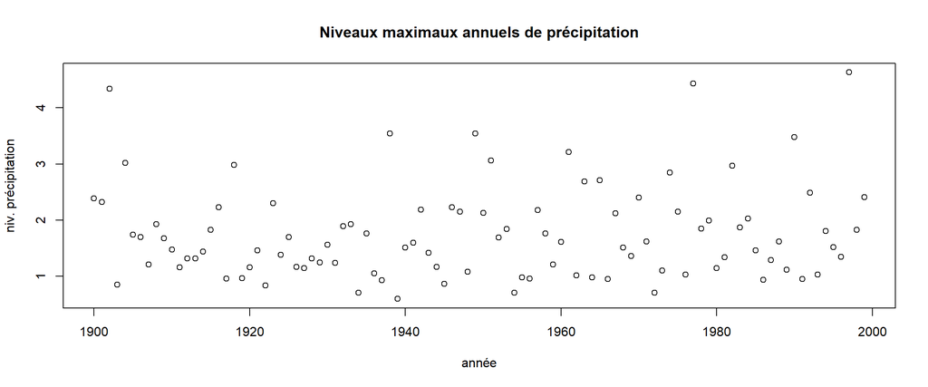

## Modèle GEV avec estimation par maximum de vraissemblance (MLE)

Les coefficients du modèle GEV, a (position), b (échelle), gamma (forme) sont estimés par maximum de vraissemblance (fonction *fevd*). A partir de la valeur estimée du paramètre forme, on déduira le domaine d’attraction des maxima, auquel appartient la loi caractérisant le comportement des niveaux de précipitations extrêmes.

```
##
## fevd(x = bmFort$Prec, type = "GEV", method = "MLE")
##
## [1] "Estimation Method used: MLE"
##
##
##  Negative Log-Likelihood Value:  104.9645
##
##
##  Estimated parameters:
##  location     scale     shape
## 1.3466597 0.5328046 0.1736264
##
##  Standard Error Estimates:
##   location      scale      shape
## 0.06168793 0.04878843 0.09195458
##
##  Estimated parameter covariance matrix.
##              location         scale         shape
## location  0.003805401  0.0017067043 -0.0020838301
## scale     0.001706704  0.0023803113 -0.0008692638
## shape    -0.002083830 -0.0008692638  0.0084556445
##
##  AIC = 215.9291
##
##  BIC = 223.7446
```

```
## fevd(x = bmFort$Prec, type = "GEV", method = "MLE")
##
## [1] "Normal Approx."
##
##          95% lower CI  Estimate 95% upper CI
## location  1.225753534 1.3466597    1.4675658
## scale     0.437181061 0.5328046    0.6284282
## shape    -0.006601292 0.1736264    0.3538540
```

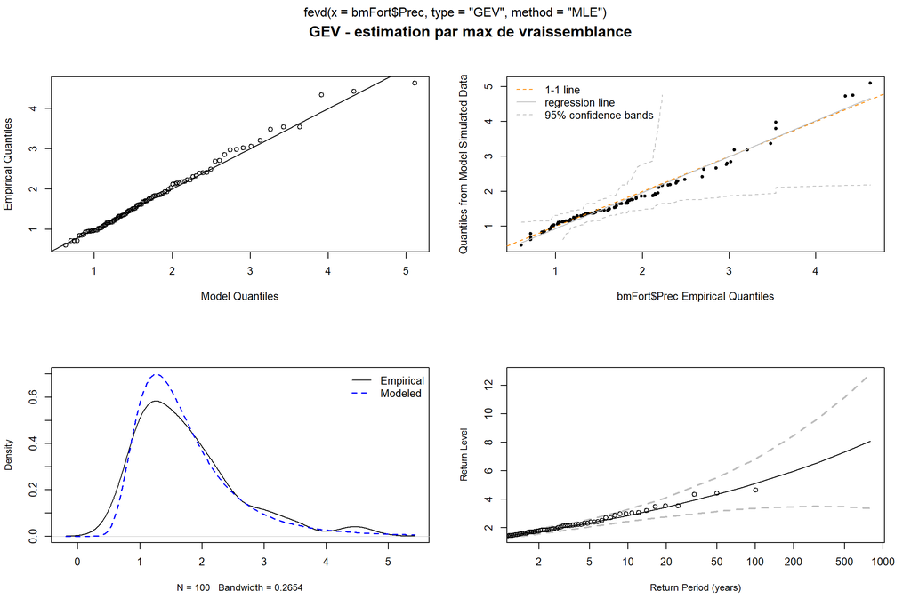

```
## fevd(x = bmFort$Prec, type = "GEV", method = "MLE")
##
## [1] "Normal Approx."
##
## [1] "100-year return level: 5.099"
##
## [1] "95% Confidence Interval: (3.3542, 6.8431)"
```

```
## fevd(x = bmFort$Prec, type = "GEV", method = "MLE")
##
## [1] "Normal Approx."
##
## [1] "1000-year return level: 8.459"
##
## [1] "95% Confidence Interval: (3.2889, 13.6292)"
```

**Domaine d’attraction des valeurs extrêmes**

La valeur estimée de gamma (shape) est de 0.17 > 0. Elle caractérise le domaine d’attraction de Fréchet. Cependant l’intervalle de confiance du paramètre gamma nous indique qu’il pourrait être négatif (borne inférieure du CI <0). Nous testerons ci-après, le résultat de la modélisation pour gamma = 0 (domaine de Gumbel).  
Les 4 graphiques montrent un bon ajustement de la loi des extrêmes au DMA de Fréchet (proximité des points théoriques/empiriques/modélisés).

**Niveaux de retour à 100 ans et 1000 ans**

Notons déjà le niveau de retour à 100 ans à 5.1 pouces. Celui à 1000 ans est de 8.5 pouces avec un intervalle large, qui révèle une forte incertude sur la valeur ponctuelle estimée.

## Modèle Gumbel avec MLE

Nous testons ici l’appartenance du modèle des extrêmes au domaine de Gumbel : autrement dit, gamma =0 est il vraissemblable?

```
##
## fevd(x = bmFort$Prec, type = "Gumbel", method = "MLE")
##
## [1] "Estimation Method used: MLE"
##
##
##  Negative Log-Likelihood Value:  107.1278
##
##
##  Estimated parameters:
##  location     scale
## 1.3988265 0.5784564
##
##  Standard Error Estimates:
##   location      scale
## 0.06059952 0.04736171
##
##  Estimated parameter covariance matrix.
##              location        scale
## location 0.0036723022 0.0008553822
## scale    0.0008553822 0.0022431316
##
##  AIC = 218.2555
##
##  BIC = 223.4659
```

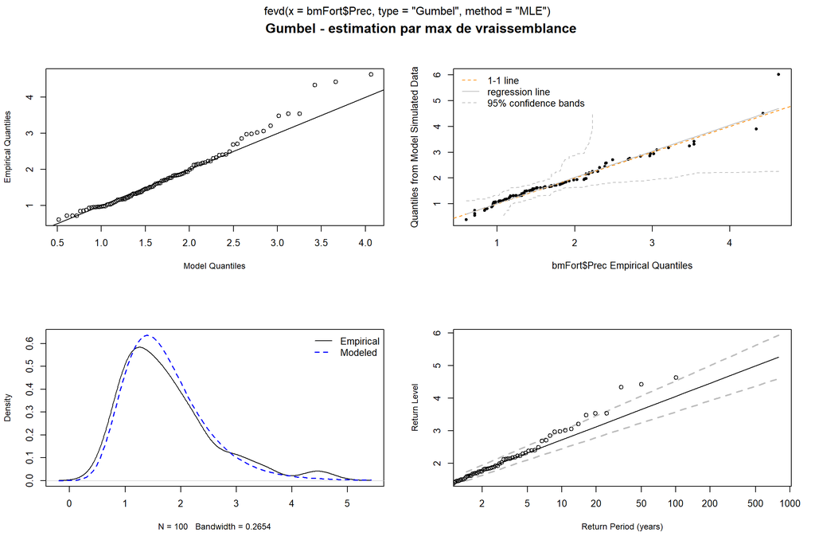

## Modèle GEV avec estimation par la méthode des moments (PWM)

Ici, les coefficients du modèle GEV (position, échelle, forme) sont estimés par la méthode des moments.

```
## fevd(x = bmFort$Prec, type = "GEV", method = "Lmoments")
## [1] "GEV  Fitted to  bmFort$Prec  using L-moments estimation."
##  location     scale     shape
## 1.3535282 0.5564335 0.1307426
```

```
## fevd(x = bmFort$Prec, type = "GEV", method = "Lmoments")
##
## [1] "Parametric Bootstrap"
## 502  iterations
##
##                2.5%  Estimate     97.5%
## location  1.2430714 1.3535282 1.4756825
## scale     0.4570847 0.5564335 0.6595172
## shape    -0.0441030 0.1307426 0.2701776
```

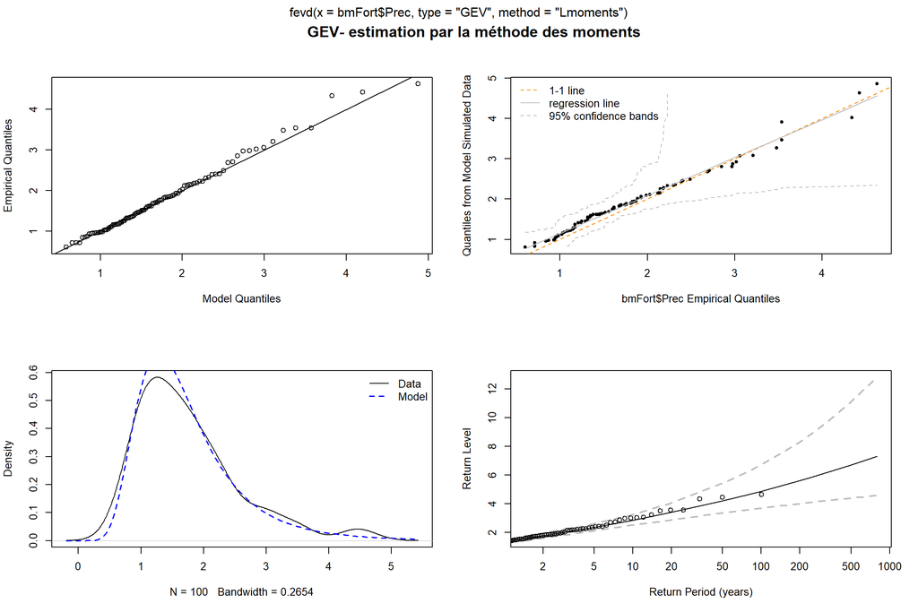

```
## fevd(x = bmFort$Prec, type = "GEV", method = "Lmoments")
##
## [1] "Parametric Bootstrap"
## 502  iterations
##
## [1] "100-year level: 4.864"
##
## [1] "95% Confidence Interval: (3.6716, 6.5085)"
```

```
## fevd(x = bmFort$Prec, type = "GEV", method = "Lmoments")
##
## [1] "Parametric Bootstrap"
## 502  iterations
##
## [1] "1000-year level: 7.598"
##
## [1] "95% Confidence Interval: (4.9213, 12.9743)"
```

**Domaine d’attraction des valeurs extrêmes**

La valeur estimée de gamma (shape) est là aussi positive (=0.13). Les 4 graphiques montrent un ajustement de la loi des extrêmes au DMA de Fréchet un peu moins bon que celui de l’estimation des paramètres par maximum de vraissemblance.

**Niveaux de retour à 100 ans et 1000 ans**

Le niveau de retour à 100 ans est ici à 4.9 pouces. Celui à 1000 ans est de 7.6 pouces. Les intervalles de confiance sont moins larges qu’avec les estimations à partir du maximum de vraissemblance.

# Modélisation Generalized Pareto Distribution (GPD) : loi des excès de la série

Il s’agit ici d’envisager les valeurs extrêmes comme les valeurs dépassant un seuil à fixer et de modéliser les dépassements (excès).

## Choix du seuil

**Etude graphique par MRL plot**

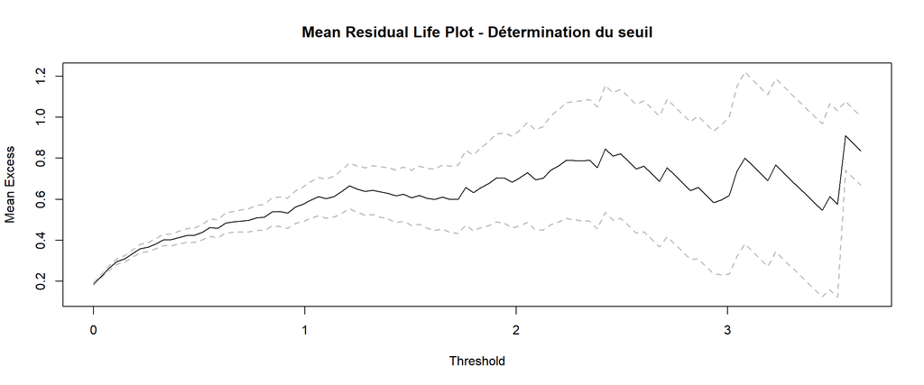

Le graphique “Mean Residual Life Plot” permet d’évaluer une valeur de seuil de la distribution de Pareto (loi des excès). Ce seuil est identifié par une rupture de “linéarité” de la courbe. On observe ici ce changement de comportement autour du niveau de 2.5 pouces.

**Seuils en fonction du nombre de dépassements**

Une autre méthode pour évaluer le seuil est de tester plusieurs seuils en fonction du nombre d’excès observés au delà de celui-ci (fonction *findThreshold*). On cherche les seuils correspondant au nombre d’excès suivants :

```
##  n=1  n=5 n=10 n=20
## 4.43 3.48 2.98 2.32
```

D’après cette approche, au dessus d’un seuil à 2.98 pouces, on a 10 jours de précipitations observés, soit 1 jour tous les 10 ans. A cette fréquence, l’évènement commence à être rare : Ce seuil de 2.98 pouces peut être considéré comme convenable pour definir des valeurs extrêmes.

**Seuils en fonction de la stabilité des estimateurs**  
Traçons le graphique des valeurs des paramètres en fonction des seuils, afin d’observer graphiquement le comportement des paramètres.  
fonction *threshrange.plot*

[output not shown]

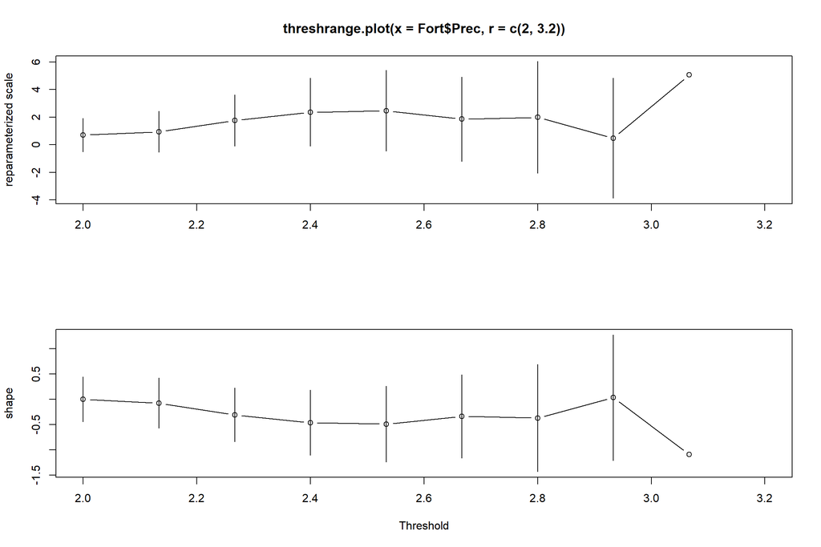

Il apparait sur ces 2 graphiques, une rupture de stabilité des paramètres pour un seuil autour de 2.9. Choisissons cette valeur pour seuil.

## Modèle GPD avec MLE

A partir d’un seuil fixé, les coefficients du modèle GDP (échelle, forme) sont estimés par maximum de vraissemblance.

```
##
## fevd(x = Fort$Prec, threshold = seuil, type = "GP", method = "MLE",
##     time.units = "days")
##
## [1] "Estimation Method used: MLE"
##
##
##  Negative Log-Likelihood Value:  6.156917
##
##
##  Estimated parameters:
##      scale      shape
##  0.7565302 -0.2079106
##
##  Standard Error Estimates:
##     scale     shape
## 0.5168627 0.6221178
##
##  Estimated parameter covariance matrix.
##           scale      shape
## scale  0.267147 -0.3031840
## shape -0.303184  0.3870306
##
##  AIC = 16.31383
##
##  BIC = 17.28365
```

```
## fevd(x = Fort$Prec, threshold = seuil, type = "GP", method = "MLE",
##     time.units = "days")
##
## [1] "Normal Approx."
##
##       95% lower CI   Estimate 95% upper CI
## scale   -0.2565021  0.7565302     1.769562
## shape   -1.4272391 -0.2079106     1.011418
```

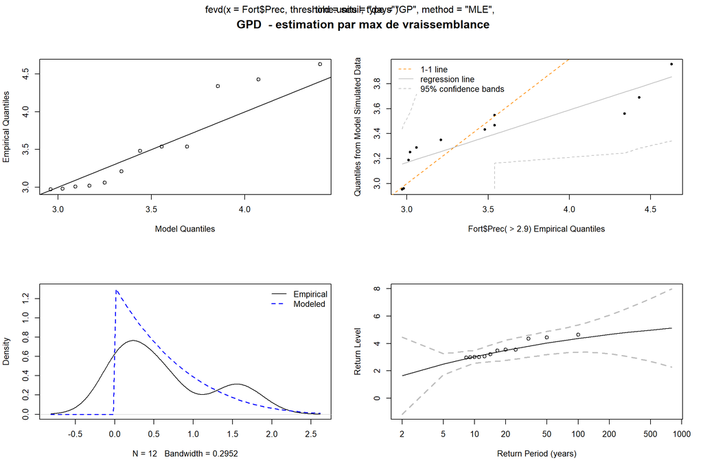

```
## fevd(x = Fort$Prec, threshold = seuil, type = "GP", method = "MLE",
##     time.units = "days")
##
## [1] "Normal Approx."
##
## [1] "100-year return level: 4.368"
##
## [1] "95% Confidence Interval: (3.3802, 5.3561)"
```

```
## fevd(x = Fort$Prec, threshold = seuil, type = "GP", method = "MLE",
##     time.units = "days")
##
## [1] "Normal Approx."
##
## [1] "1000-year return level: 5.194"
##
## [1] "95% Confidence Interval: (2.0774, 8.3104)"
```

**Domaine d’attraction**

La valeur estimée de gamma (shape) est négatif : -0.21< 0 . Elle caractérise le domaine d’attraction de Weibull. Cependant l’intervalle de confiance du paramètre gamma nous indique qu’il pourrait être positif (borne supérieure du CI >0). Nous testerons ci-après, le résultat de la modélisation pour gamma = 0 (domaine de Gumbel).

**Point final**

Dans le cas d’un domaine de Weibull, les niveaux de retour seront remplacés par le *point final*. Il s’agit de la valeur extrême qui ne pourra pas être dépassée : limite intrinsèque du phénomène observé (physique, technologique, physiologique…).  
Ici le point final est de 6.54 pouces . On peut se demander si une limite a du sens concernant un niveau de précipitation?

## Modèle GPD Gumbel avec MLE

Testons l’hypothèse de nullité du paramètre de forme, à savoir la distribution Gumbel des excès.

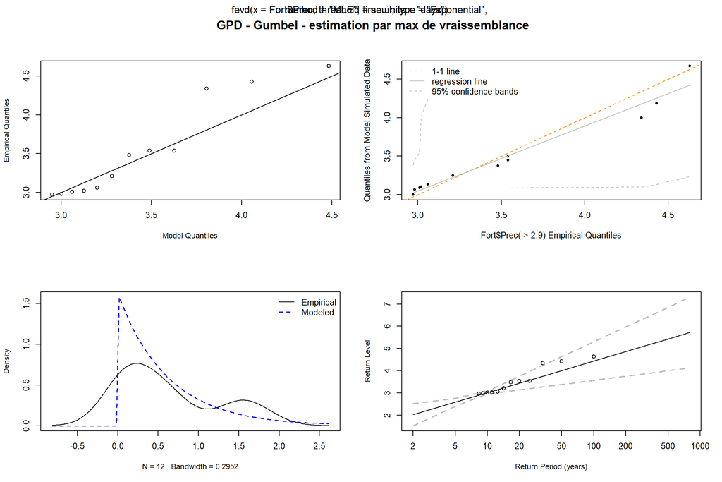

L’ajustement présenté sur les graphiques ne donne pas de meilleurs résultats que sur les précédents. On ne retient pas l’hypothèse de la nullité du parametre forme.

## Modèle GPD avec PWM

A partir d’un seuil fixé, les coefficients du modèle GDP (échelle, forme) sont estimés par la méthode des moments.

```
## fevd(x = Fort$Prec, threshold = seuil, type = "GP", method = "Lmoments",
##     time.units = "days")
## [1] "GP  Fitted to  Fort$Prec  using L-moments estimation."
##     scale     shape
## 0.5027409 0.1858446
```

```
## fevd(x = Fort$Prec, threshold = seuil, type = "GP", method = "Lmoments",
##     time.units = "days")
##
## [1] "Parametric Bootstrap"
## 502  iterations
##
##             2.5%  Estimate    97.5%
## scale  0.2111365 0.5027409 1.161006
## shape -0.7486476 0.1858446 0.641964
```

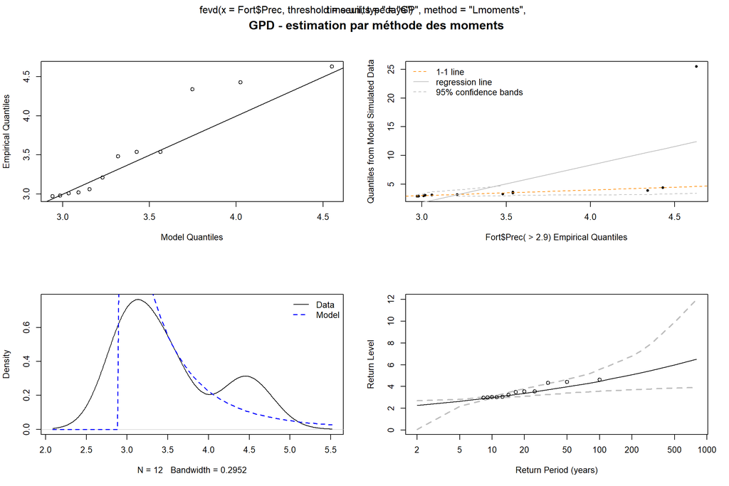

```
## fevd(x = Fort$Prec, threshold = seuil, type = "GP", method = "Lmoments",
##     time.units = "days")
##
## [1] "Parametric Bootstrap"
## 502  iterations
##
## [1] "100-year level: 4.488"
##
## [1] "95% Confidence Interval: (3.5744, 5.6963)"
```

```
## fevd(x = Fort$Prec, threshold = seuil, type = "GP", method = "Lmoments",
##     time.units = "days")
##
## [1] "Parametric Bootstrap"
## 502  iterations
##
## [1] "1000-year level: 6.781"
##
## [1] "95% Confidence Interval: (3.8703, 14.1449)"
```

La valeur estimée de gamma (shape) est positif (0.19> 0). On retient ici le domaine de Fréchet.

**Niveaux de retour à 100 ans et 1000 ans**

# Conclusion

[output not shown]

Finalement, la méthode retenue est :

**Distribution de Pareto généralisée (GPD) / Moments**